# Exploring Virginia HomeHealth Care Industry

Abiyu Giday

February 24, 2016

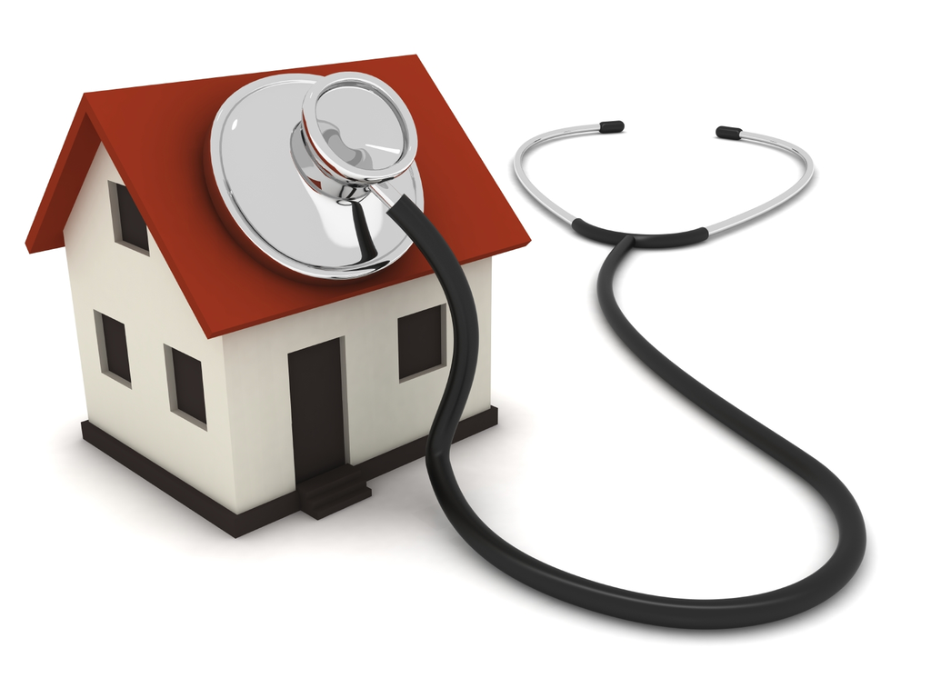

The healthcare industry is one of the world’s largest and fastest-growing industries. Consuming over 10 percent of gross domestic product (GDP) of most developed nations, health care can form an enormous part of a country’s economy. Home health care Medicare-certified services may include short-term nursing, rehabilitative, therapeutic, and assistive home health care. Home health agencies provide services to beneficiaries who are homebound and need skilled nursing or therapy. In 2011, about 3.4 million Medicare beneficiaries received home care, and the program spent about $18.4 billion on home health services. The number of agencies participating in Medicare reached 12,199 in 2012.

The questions this paper attempt to answer are the following:

> *Did HHC agency’s high positive patient rating resulted in higher revenue?*  
> _Which home health care provider in Virginia had the highest/lowest patient recommendation?__  
> *On average which type of ownership HHC generated the highest revenue?*

Question that can be answered to increase service and marketshare but are not included here are the following.  
* **How does HHC “abc”" rating/revenue compare to its local county, State wide and the entire US competitors?**  
* **What are the important metrics for HHC agency “abc” to improve increase patient rating?**  
* **Which hospital refers the most HHC customers to agency’s?**  
* **What is the seasonal pattern for the number of patients available?** * **What is the profile of the top 10 types of customers (age, sickness type, average amount billed)?**  
* **Can we predict the customers who are likely to go back to the hospital?** * **For marketing what is the demographic in my local and neighboring county?**

## Virginia Home Health Care providers

| prvdr.id | prvdr.name | own.type | address | city | state | zip | prctRcmd | smryRtg | patientOverallRtg | mdcr.paymnt |
| --- | --- | --- | --- | --- | --- | --- | --- | --- | --- | --- |
| 497268 | SENTARA HOMECARE SERVICES | Local | 535 INDEPENDENCE PARKWAY SUITE 200 | CHESAPEAKE | VA | 23320 | 76 | 3 | 3 | 20550983 |
| 497008 | INOVA VNA HOME HEALTH | Visiting Nurse Association | 9900 MAIN STREET | FAIRFAX | VA | 22031 | 81 | 4 | 4 | 12012571 |
| 497429 | GENTIVA HEALTH SERVICES | Local | 1302 PLANTATION ROAD | ROANOKE | VA | 24012 | 81 | 4 | 4 | 11579607 |
| 497493 | AT HOME CARE | Local | 4110 FITZHUGH AVENEUE | RICHMOND | VA | 23230 | 79 | 4 | 4 | 11313692 |
| 497538 | AMEDISYS HOME HEALTH | Local | 4589 LIFESTYLE LANE | MIDLOTHIAN | VA | 23112 | 79 | 5 | 4 | 8772085 |
| 497653 | ENCOMPASS HOME HEALTH OF VIRGINIA | Local | 1606 SANTA ROSA ROAD, SUITE 109 | RICHMOND | VA | 23229 | 74 | 4 | 4 | 8170578 |
| 497467 | RIVERSIDE HOME HEALTH | Hospital Based Program | 856 J CLYDE MORRIS BLVD SUITE C | NEWPORT NEWS | VA | 23601 | 81 | 4 | 4 | 7945373 |
| 497245 | BON SECOURS HOME CARE | Hospital Based Program | 485 RODMAN AVENUE | PORTSMOUTH | VA | 23707 | 74 | 3 | 3 | 7602883 |
| 497593 | LIVINRITE HOME HEALTH SERVICES | Local | 12269 LIVINGSTON RD, SUITE 201 | MANASSAS | VA | 20109 | 81 | 4 | 4 | 7467345 |
| 497275 | AMEDISYS HOME HEALTH CARE | Local | 5221 VALLEY PARK DRIVE, SUITE 1A | ROANOKE | VA | 24019 | 85 | 4 | 4 | 7321743 |

[output cut: 20 more lines]

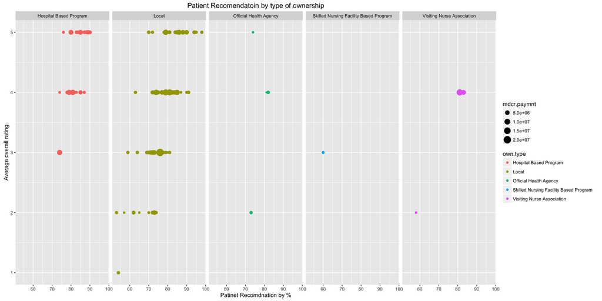

Patinet Recomendation and overall rating.

## Patient’s rating of HHC agencies from 0 - 100.

[output not shown]

### Top 10 highest Patient Recommended HHC in Virginia

|  | prvdr.name | prctRcmd | smryRtg | patientOverallRtg |
| --- | --- | --- | --- | --- |
| 1 | HELPING HANDS HOME HEALTH CARE,INC | 98 | 5 | 5 |
| 2 | FIRST CHOICE HOME HEALTH CARE | 95 | 5 | 5 |
| 3 | SOUTHWEST VA HOME HEALTH CARE | 94 | 5 | 5 |
| 4 | MEDI HOME HEALTH AND HOSPICE | 91 | 4 | 5 |
| 5 | HOME NURSING SERVICES OF SOUTHWEST VA INC | 90 | 5 | 5 |
| 6 | AMEDISYS HOME HEALTH CARE | 90 | 5 | 5 |
| 7 | CARILION HOME CARE SERVICES | 90 | 5 | 5 |
| 8 | SENIOR INDEPENDENCE | 90 | 4 | 5 |
| 9 | MARY WASHINGTON HOME HEALTH AGENCY | 89 | 5 | 5 |
| 10 | CIRCLE HOME CARE | 89 | 5 | 5 |

### Bottom 10 lowest Patient Recommended HHC in Virginia

|  | prvdr.name | prctRcmd | smryRtg | patientOverallRtg |
| --- | --- | --- | --- | --- |
| 1 | INTERIM HEALTHCARE OF ROANOKE | 65 | 2 | 2 |
| 2 | PROFESSIONAL HEALTHCARE RESOURCES, INC | 64 | 3 | 3 |
| 3 | INTREPID USA HEALTHCARE SERVICES | 63 | 4 | 3 |
| 4 | BROOKDALE HOME HEALTH RICHMOND | 62 | 2 | 2 |
| 5 | GREENSPRING VILLAGE HOME SUPPORT SERVICES | 60 | 3 | 2 |
| 6 | HOPE IN HOME CARE, LLC | 59 | 3 | 2 |
| 7 | MEDSTAR HEALTH VISTING NURSE ASSOCIATION | 58 | 2 | 1 |
| 8 | INTERIM HEALTHCARE - CHRISTIANSBURG | 57 | 2 | 2 |
| 9 | VIRGINIA HEALTHCARE SERVICES | 54 | 1 | 1 |
| 10 | PROFESSIONAL HEALTHCARE RESOURCES, INC | 53 | 2 | 2 |

### Boxplot Virginia HHC ownership types

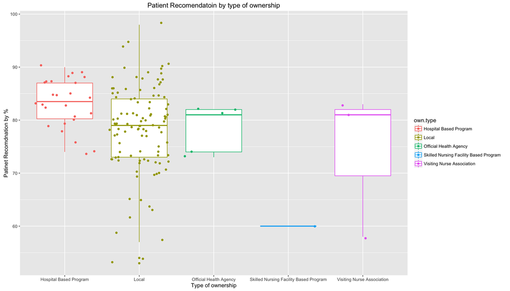

Box plot Virginia HHC by ownership type.

## Types of ownership count in Virginia

| own.type | count |
| --- | --- |
| Hospital Based Program | 27 |
| Local | 188 |
| Official Health Agency | 12 |
| Skilled Nursing Facility Based Program | 1 |
| Visiting Nurse Association | 4 |
|  | 14 |

### Types of ownership By County

| city | count |
| --- | --- |
| RICHMOND | 22 |
|  | 14 |
| FALLS CHURCH | 11 |
| VIRGINIA BEACH | 10 |
| ALEXANDRIA | 9 |
| ANNANDALE | 8 |
| FAIRFAX | 7 |
| NORFOLK | 7 |
| ROANOKE | 7 |
| DANVILLE | 6 |

[output cut: 73 more lines]

## which type of ownership made the most income from medicare

|  | own.type | mdcr.paymnt |
| --- | --- | --- |
| 1 | Visiting Nurse Association | 4751415 |
| 2 | Hospital Based Program | 2816954.18518519 |
| 3 | Local | 2093686.00645161 |
| 4 |  | 1265164.5 |
| 5 | Skilled Nursing Facility Based Program | 1038793 |
| 6 | Official Health Agency | 680840.727272727 |

## Bar chart type of ownership revenue from medicare

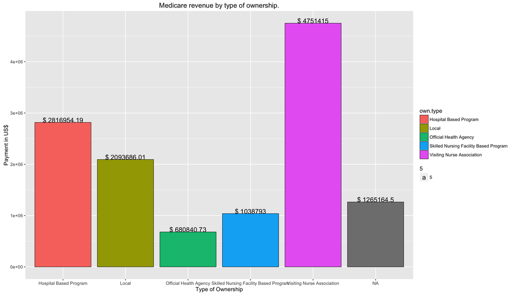

Medicare revenue by type of ownership.

## Is there correlation between Patient’s sentiment to higher revenue?

[interactive chart not shown]

## Services offered by HHC providers

| prvdr.id | prvdr.name | srvc.nrsg | srvc.phscl.trpy | srvc.ocptn.trpy | srvc.spch.trpy | srvc.mdcl.scl | srvc.hlth.aid |
| --- | --- | --- | --- | --- | --- | --- | --- |
| 497005 | SHELTERING ARMS HOME HEALTHCARE, LLC | true | true | true | true | true | true |
| 497008 | INOVA VNA HOME HEALTH | true | true | true | true | true | true |
| 497011 | HOME HEALTH INC | true | true | true | true | true | true |
| 497015 | FAMILY CARE SENIOR SOLUTIONS | true | true | true | true | false | true |
| 497018 | CARILION HOME CARE SERVICES TAZEWELL | true | true | true | true | true | true |
| 497019 | SENTARA HOME CARE SERVICES | true | true | true | true | true | true |
| 497020 | BUCHANAN GENERAL HOSPITAL HOME HEALTH AGENCY | true | true | true | true | false | true |
| 497021 | COMMONWEALTH HOME HEALTH INC | true | true | true | true | false | true |
| 497022 | INTERIM HEALTHCARE OF ROANOKE | true | true | true | true | true | true |
| 497025 | RIVERSIDE TAPPAHANNOCK HOME HEALTH | true | true | false | true | false | true |

[output cut: 222 more lines]

## Take Aways:

1. HHC agencies who had a higher patient recommendation generally show higher revenue and the once with lower patient rating earned less. But there were few exceptions. For example, the highest 4 revenue earners had their patient rating ranging only between 75% and 82%.
2. With 98% patient recommendation and 5 out of 5 star rating **Helping hands home health care, Inc** ranked at the very top, while **Professional health care resources, Inc** was at the bottom with 53% patient recommendation and 2 out of 5 starting.
3. With the average earning of $4.7 million the *Visiting Nurse association* agencies earned the highest. Followed by *Hospital based programs* with the average of $2.8 Million. Official health Agencies had the lowest revenue with average earnings of $680 thousand.

## To Do

1. Compare the services and ratings of HHC in the lower 70% to the top 30%.
2. Specific recomendation how to improve on patient ratings.
3. Develop Shiny app to be used by HHC for identifying strength and weakness
4. Develop model to identify thelikey patients to go back to hospitals based specific demographics.
5. Model to identify potential customers based on demographics in the county
6. Incorporate Apendix Information into the shiny app.

## Professionals providing home care include

- licensed practical nurses,
- registered nurses,
- home health aides,
- physical therapists,
- occupational therapists and
- social workers.

## Rehabilitation services may be provided by

- physical therapists,
- occupational therapists,
- speech and
- language pathologists and
- dietitian

## Who pays

- Medicare/Medicaid
- private insurance, or
- self/family
- Private insurance includes VA (Veterans Administration),
- some Railroad or Steelworkers health plans

## TYPE of Services offered

- Offers Nursing Care Services
- Offers Physical Therapy Services
- Offers Occupational Therapy Services
- Offers Speech Pathology Services
- Offers Medical Social Services
- Offers Home Health Aide Services

## Patient Rating of Home Health Care Agencies:

- Percent of patients who reported that their home health team gave care in a professional way
- Footnote for percent of patients who reported that their home health team gave care in a professional way
- Percent of patients who reported that their home health team communicated well with them
- Footnote for percent of patients who reported that their home health team communicated well with them
- Percent of patients who reported that their home health team discussed medicines pain and home safety with them
- Footnote for percent of patients who reported that their home health team discussed medicines pain and home safety with them
- Star Rating for how patients rated overall care from agency
- Percent of patients who gave their home health agency a rating of 9 or 10 on a scale from 0 lowest to 10 highest
- Footnote for percent of patients who gave their home health agency a rating of 9 or 10 on a scale from 0 lowest to 10 highest
- Percent of patients who reported YES they would definitely recommend the home health agency to friends and family
- Footnote for percent of patients who reported YES they would definitely recommend the home health agency to friends and family

## Star ratings:

- HHCAHPS Survey Summary Star Rating
- Footnote HHCAHPS Survey Summary Star Rating
- Star Rating for health team gave care in a professional way
- Footnote for Star Rating for gave care in a professional way
- Star Rating for health team communicated well with them
- Footnote for Star Rating for communicated well with them
- Star Rating team discussed medicines pain and home safety
- Footnote Star Rating discussed medicines pain home safety
- Star Rating for how patients rated overall care from agency
- Footnote for Star Rating for overall care from agency